# NJ Homes Listing Prices Analysis

## Decomposition

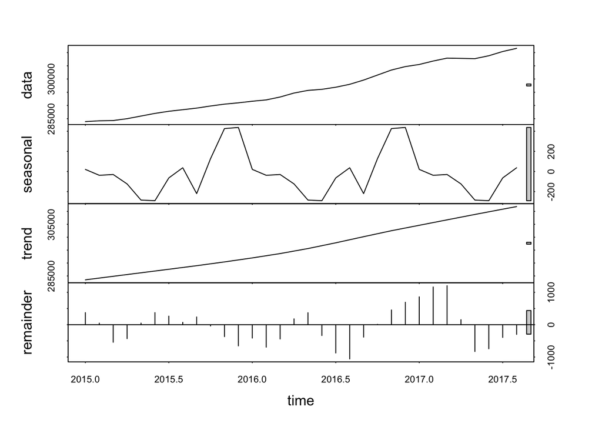

```r
library(fpp)
library(fpp2)

decomp_data <- stl(data,s.window ="periodic")

#Plot of decomposition of timeseries.
plot(decomp_data)
```

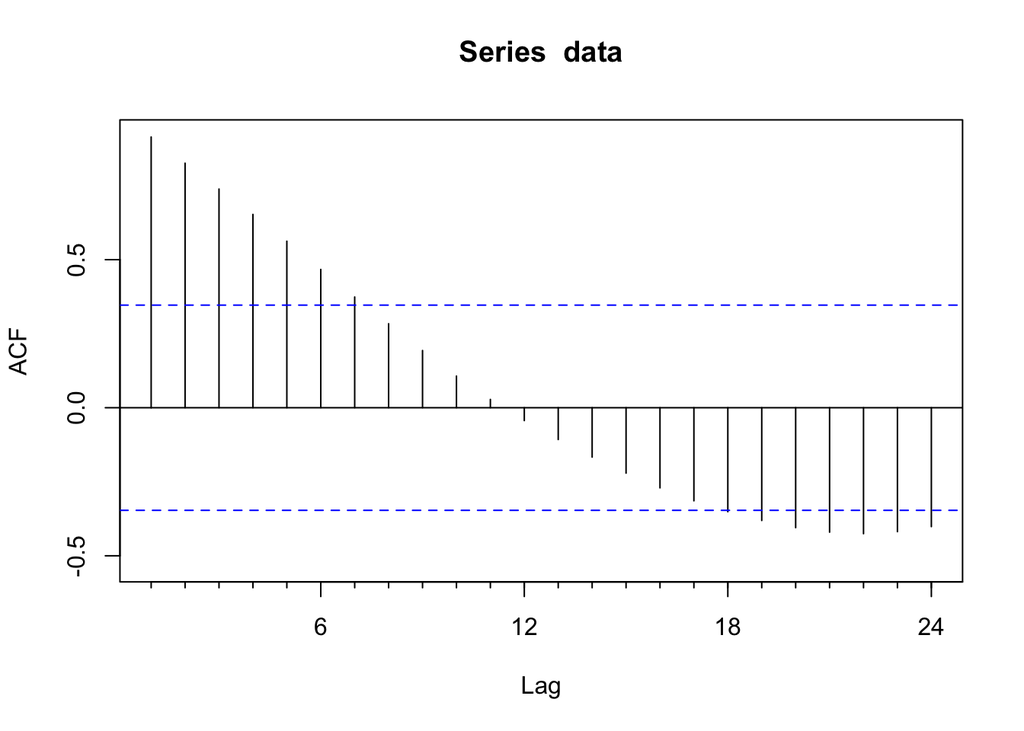

```r
Acf(data)
```

```r
decomp_data
```

```
##  Call:
##  stl(x = data, s.window = "periodic")
##
## Components
##            seasonal    trend    remainder
## Jan 2015   20.74073 283506.9   372.390604
## Feb 2015  -37.92284 284190.1    47.794900
## Mar 2015  -29.91936 284873.4  -543.467855
## Apr 2015 -123.89261 285554.8  -430.942843
## May 2015 -284.53284 286236.3    48.249148
## Jun 2015 -290.87452 286918.0   372.844768
## Jul 2015  -63.88274 287599.8   264.106934
## Aug 2015   37.18421 288290.3    72.477853
## Sep 2015 -220.33493 288980.9   239.434852
## Oct 2015  128.35377 289711.7   -40.078086
## Nov 2015  427.04246 290442.5  -369.591025
## Dec 2015  438.03794 291217.7  -655.754020
## Jan 2016   20.74073 291992.9  -413.624339
## Feb 2016  -37.92284 292833.0  -695.043626
## Mar 2016  -29.91936 293673.0  -443.129964
## Apr 2016 -123.89261 294643.9   179.958943
## May 2016 -284.53284 295614.8   369.714828
## Jun 2016 -290.87452 296726.8  -335.933402
## Jul 2016  -63.88274 297838.8  -874.915086
## Aug 2016   37.18421 299022.0 -1059.202254
## Sep 2016 -220.33493 300205.2  -384.903342
## Oct 2016  128.35377 301361.8     9.871039
## Nov 2016  427.04246 302518.3   454.645420
## Dec 2016  438.03794 303568.4   693.537037
## Jan 2017   20.74073 304618.5   860.721331
## Feb 2017  -37.92284 305671.9  1166.019426
## Mar 2017  -29.91936 306725.3  1204.650471
## Apr 2017 -123.89261 307769.5   154.364218
## May 2017 -284.53284 308813.8  -829.255057
## Jun 2017 -290.87452 309835.9  -745.074794
## Jul 2017  -63.88274 310858.1  -394.227984
## Aug 2017   37.18421 311862.9  -300.048292
```

##### Time series decomposition helps separate the time series into trend, seasonality, and residual components. This analysis revealed that:

The seasonal component is stable across the years. The trend component shows a gradual upward movement. The residual component indicates variations not captured by trend or seasonality.

##### Additive or Multiplicative Decomposition:

The decomposition appears to be additive because the seasonal variation remains consistent regardless of changes in the trend.

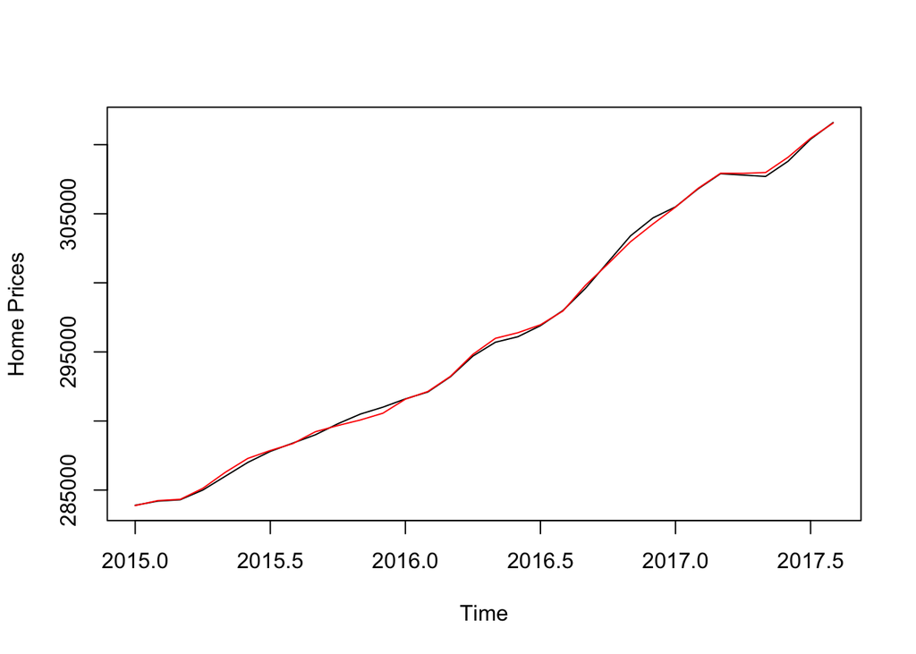

```r
SATS <- seasadj(decomp_data)
plot(data, ylab="Home Prices")
lines(SATS, col="red")
```

After overlaying the plot for time series adjusted for seasonality and the line for actual time series we can see that it somewhats fits the actual line, and there is negligible fluctuations at any point.

## Forecasting Methods and Residual Analysis

### Naïve Method

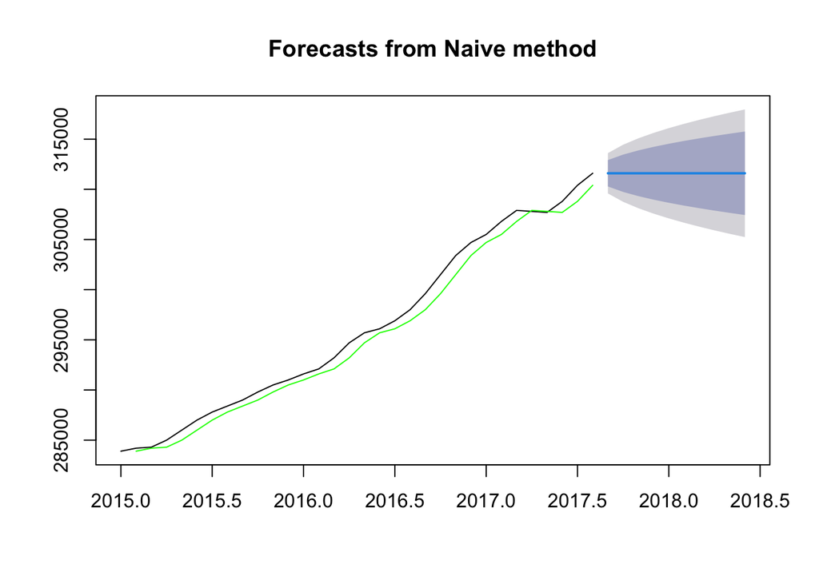

```r
#naives bayes

naive_fc = naive(data)
plot(naive_fc)
lines(naive_fc$fitted, col="green")
```

```r
accuracy(naive_fc)
```

```
##                    ME     RMSE      MAE       MPE      MAPE       MASE
## Training set 893.5484 1026.268 906.4516 0.2997294 0.3039222 0.07923528
##                   ACF1
## Training set 0.5545974
```

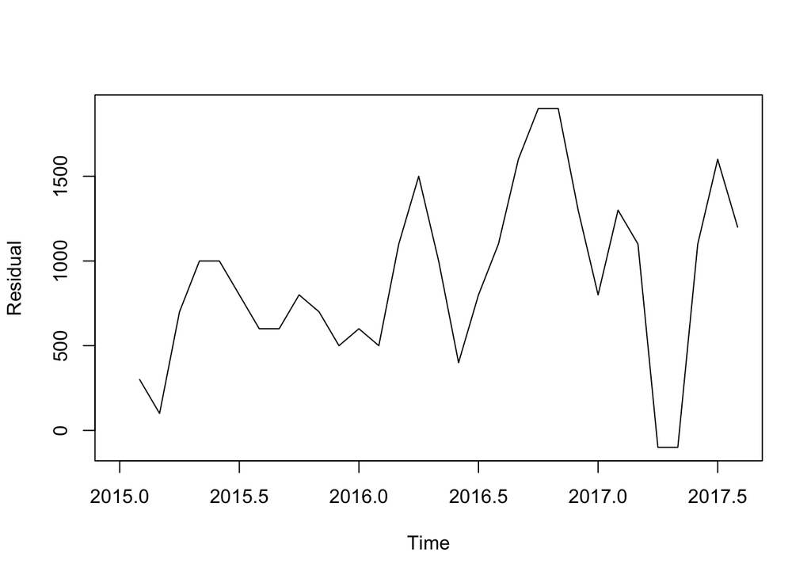

```r
naive_residual <- naive_fc$residuals
naive_fitted <- naive_fc$fitted
plot(naive_residual, ylab="Residual")
```

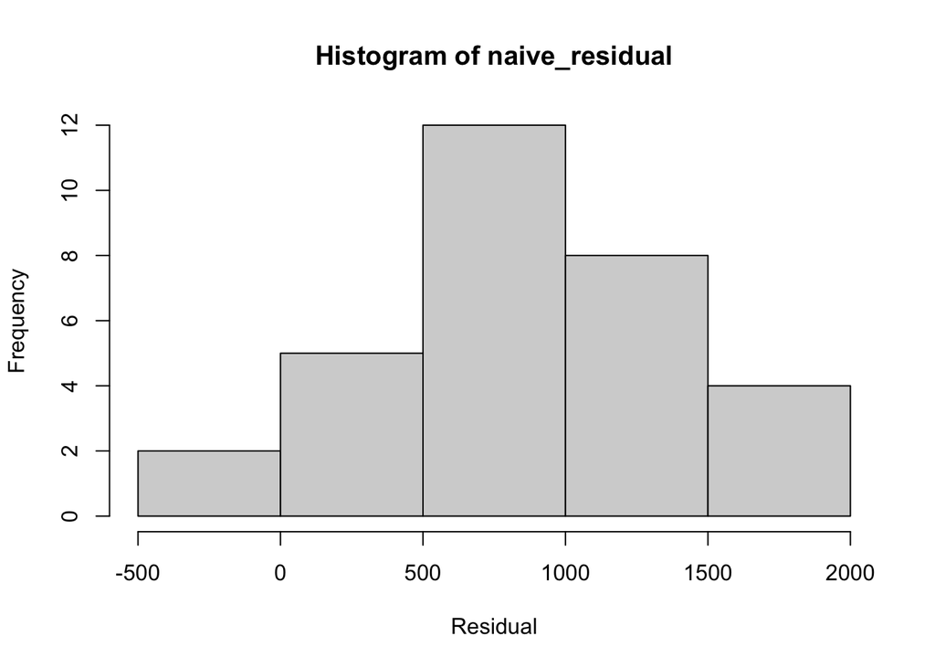

```r
hist(naive_residual, xlab="Residual")
```

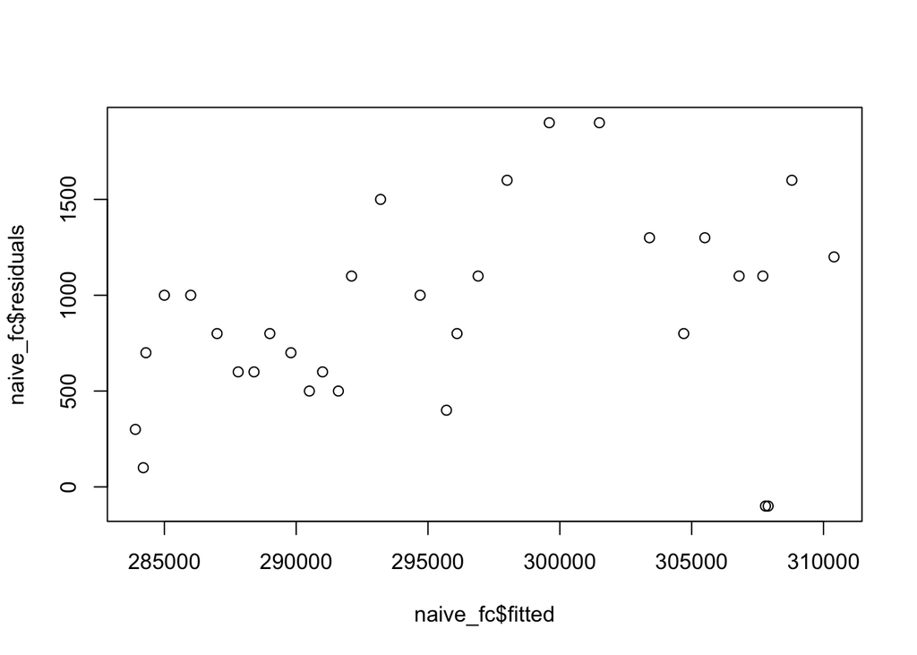

```r
plot.ts(naive_fc$fitted,naive_fc$residuals,xy.labels = FALSE,xy.lines = FALSE)
```

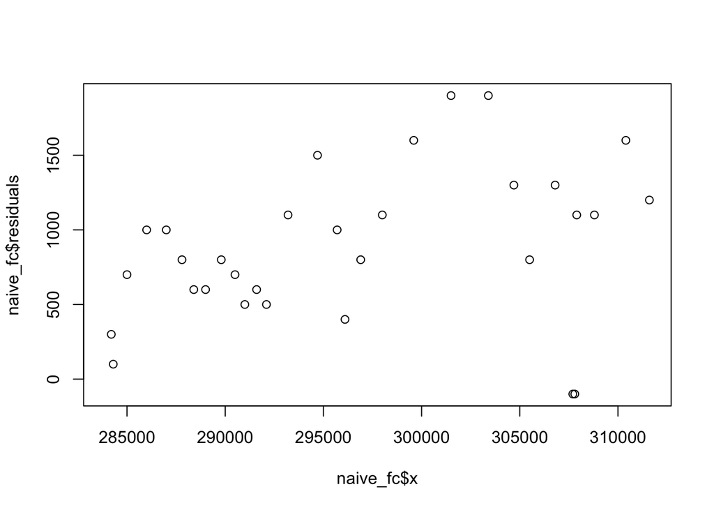

```r
plot.ts(naive_fc$x,naive_fc$residuals,xy.labels = FALSE,xy.lines = FALSE)
```

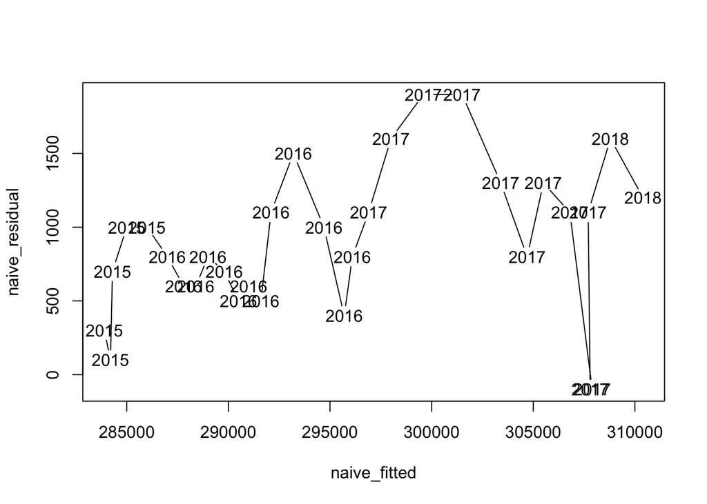

```r
plot(naive_fitted, naive_residual)
```

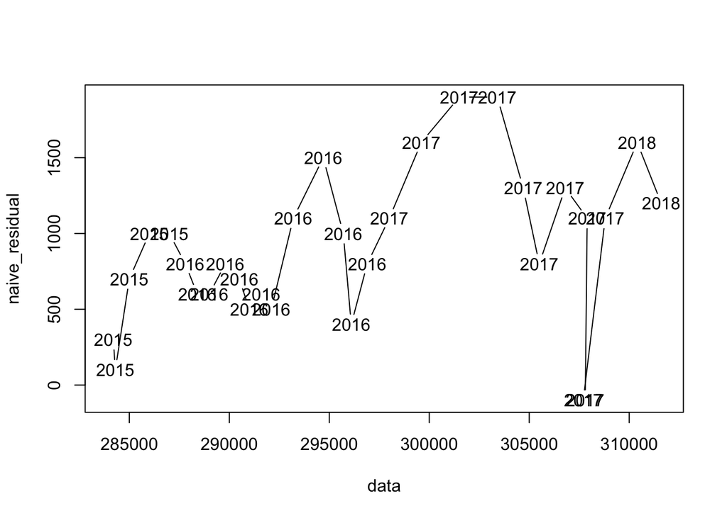

```r
plot(data, naive_residual)
```

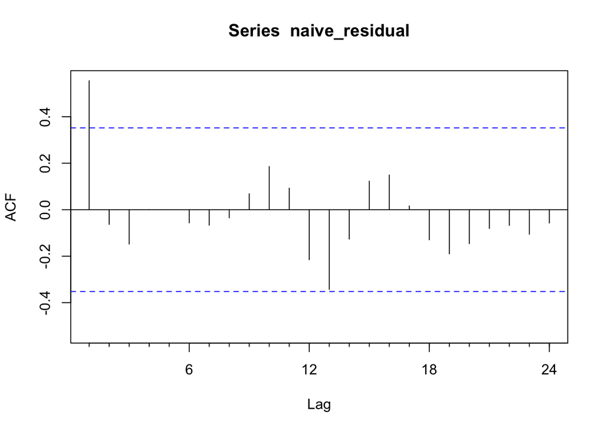

```r
Acf(naive_residual)
```

```r
accuracy(naive_fc)
```

```
##                    ME     RMSE      MAE       MPE      MAPE       MASE
## Training set 893.5484 1026.268 906.4516 0.2997294 0.3039222 0.07923528
##                   ACF1
## Training set 0.5545974
```

```r
naive_forecast <- forecast(naive_fc,20)
naive_forecast
```

```
##          Point Forecast    Lo 80    Hi 80    Lo 95    Hi 95
## Sep 2017         311600 310284.8 312915.2 309588.6 313611.4
## Oct 2017         311600 309740.0 313460.0 308755.4 314444.6
## Nov 2017         311600 309322.0 313878.0 308116.1 315083.9
## Dec 2017         311600 308969.6 314230.4 307577.1 315622.9
## Jan 2018         311600 308659.1 314540.9 307102.3 316097.7
## Feb 2018         311600 308378.4 314821.6 306673.0 316527.0
## Mar 2018         311600 308120.3 315079.7 306278.2 316921.8
## Apr 2018         311600 307880.0 315320.0 305910.8 317289.2
## May 2018         311600 307654.4 315545.6 305565.7 317634.3
## Jun 2018         311600 307440.9 315759.1 305239.2 317960.8
```

```r
accuracy(naive_forecast)
```

```
##                    ME     RMSE      MAE       MPE      MAPE       MASE
## Training set 893.5484 1026.268 906.4516 0.2997294 0.3039222 0.07923528
##                   ACF1
## Training set 0.5545974
```

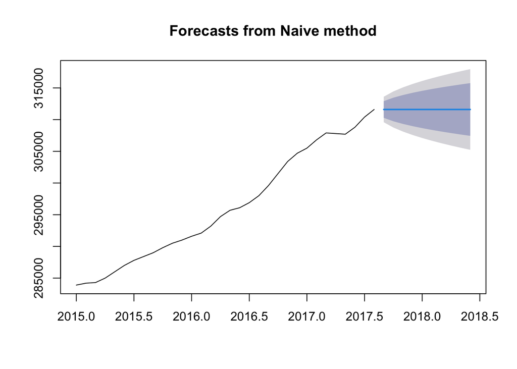

```r
plot(naive_forecast)
```

### The naive method was applied, and the residual analysis showed:

##### Residual Plot: The residuals did not have a mean of zero, indicating a potential bias in prediction.

##### ACF Plot: Shows significant autocorrelation, suggesting some patterns were not captured by the naive forecast.

### Simple Moving Averages

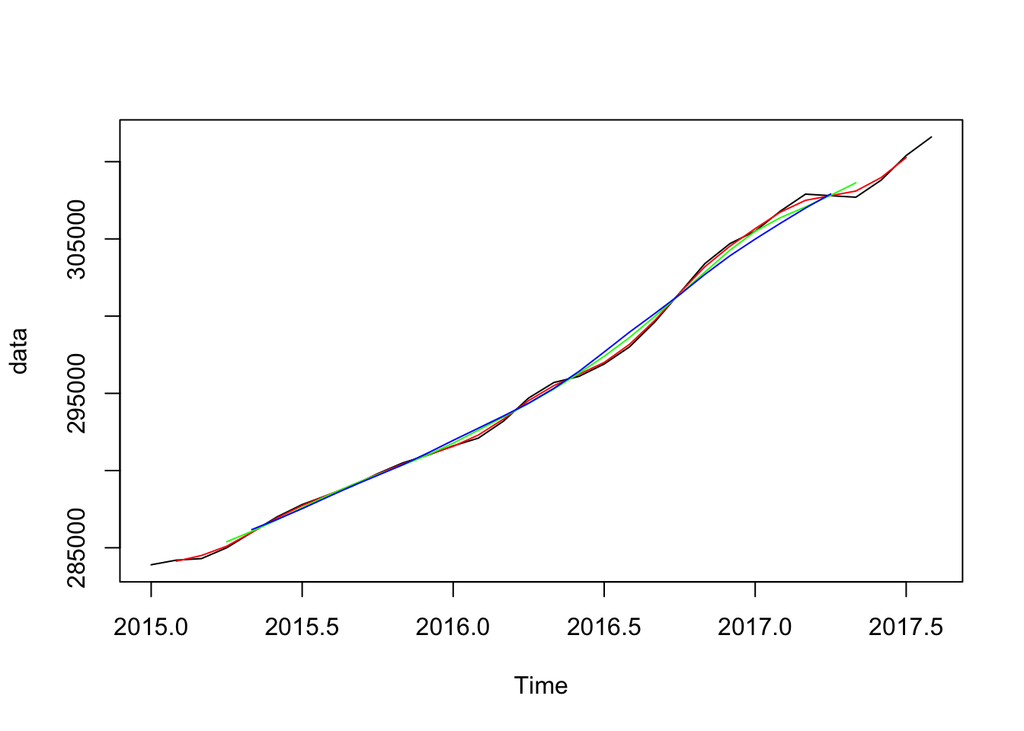

```r
#Moving Avg
ma_forecast_1 = ma(data,order=3)
ma_forecast_2 = ma(data,order=6)
ma_forecast_3 = ma(data,order=9)

plot(data)
lines(ma_forecast_1, col="red")
lines(ma_forecast_2, col="green")
lines(ma_forecast_3, col="blue")
```

#### Three different moving average orders were applied: 3, 6, and 9. It was observed that:

• Order 3 provided the closest approximation to the actual data.

• Higher orders smoothed the curve more, resulting in less accuracy in terms of short-term predictions.

### Simple Smoothing (SES)

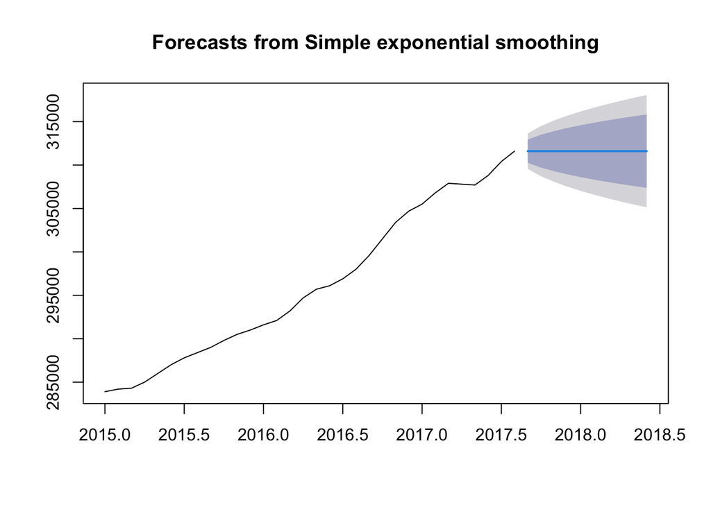

```r
#simple smoothing
ses_fc <- ses(data)
plot(ses_fc)
```

```r
summary(ses_fc)
```

```
##
## Forecast method: Simple exponential smoothing
##
## Model Information:
## Simple exponential smoothing
##
## Call:
##  ses(y = data)
##
##   Smoothing parameters:
##     alpha = 0.9999
##
##   Initial states:
##     l = 283901.0096
##
##   sigma:  1043.324
##
##      AIC     AICc      BIC
## 559.6490 560.5061 564.0462
##
## Error measures:
##                    ME     RMSE      MAE       MPE      MAPE       MASE
## Training set 865.6766 1010.194 878.2334 0.2903796 0.2944615 0.07676865
##                   ACF1
## Training set 0.5651999
##
## Forecasts:
##          Point Forecast    Lo 80    Hi 80    Lo 95    Hi 95
## Sep 2017       311599.9 310262.8 312937.0 309555.0 313644.8
## Oct 2017       311599.9 309709.1 313490.7 308708.1 314491.6
## Nov 2017       311599.9 309284.2 313915.6 308058.3 315141.5
## Dec 2017       311599.9 308925.9 314273.8 307510.4 315689.3
## Jan 2018       311599.9 308610.3 314589.4 307027.8 316172.0
## Feb 2018       311599.9 308325.0 314874.8 306591.4 316608.4
## Mar 2018       311599.9 308062.6 315137.1 306190.1 317009.7
## Apr 2018       311599.9 307818.4 315381.4 305816.6 317383.2
## May 2018       311599.9 307589.0 315610.7 305465.8 317734.0
## Jun 2018       311599.9 307372.1 315827.7 305134.0 318065.8
```

```r
attributes(ses_fc)
```

```
## $names
##  [1] "model"     "mean"      "level"     "x"         "upper"     "lower"
##  [7] "fitted"    "method"    "series"    "residuals"
##
## $class
## [1] "forecast"
```

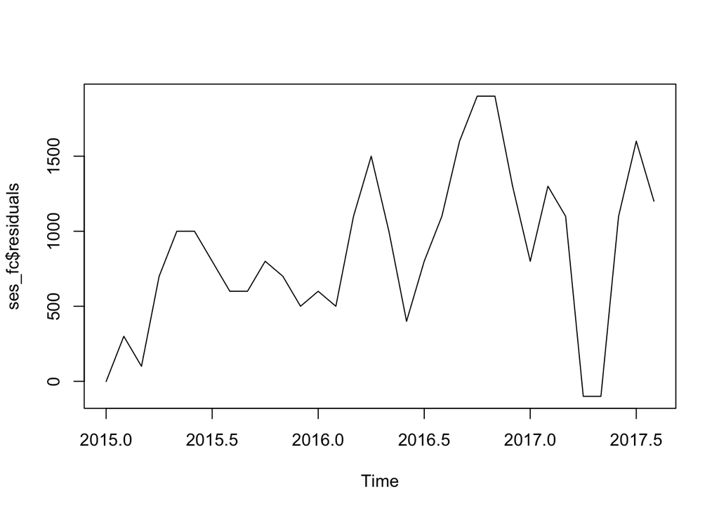

```r
plot(ses_fc$residuals)
```

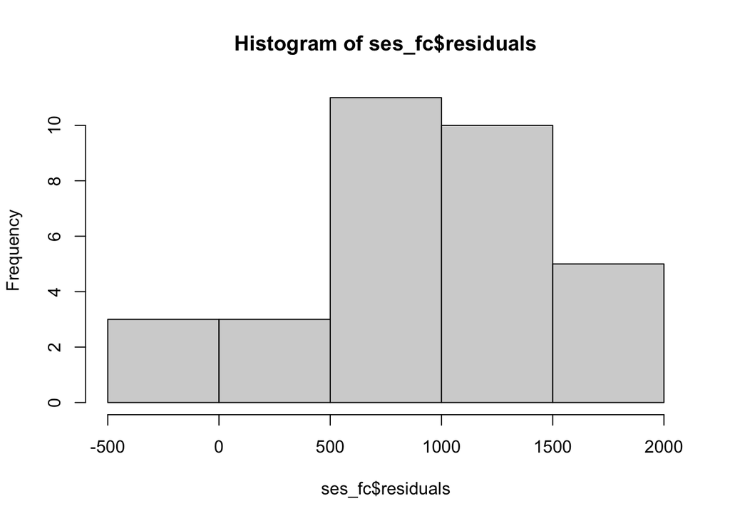

```r
hist(ses_fc$residuals)
```